# Rapport de Business Intelligence,

### Massyl Gheroufella et Emmanuel de Bézenac,

## master DAC, UPMC

#### Problématique:

Nous avons décidés de nous concentrer sur les données des restaurants en France, plus particulièrement à Paris et à Avignon, et de les exploiter afin de présenter des rapports et charts du suivi de qualité des restaurants, ainsi que la disponibilité d'une terrasse ou un étalage.

Nous avons fait 3 schémas en étoile, en récupérant les données à l'aide de plusieures méthodes différentes: en téléchargent des données accessibles depuis https://www.opendata.paris.fr et https://www.data.gouv.fr, et faisant du webscraping depuis le site https://www.yelp.fr et https://www.bilansgratuits.fr.

Voici un compte rendu récapitulant le travail fait à ce jour.

# Aperçus des schémas: 1ère partie

## Schéma 1: Restaurants à Paris ayant une terrasse ou un étalage.

Le fichier de base à été téléchargé depuis le lien suivant: http://opendata.paris.fr/explore/dataset/etalages_et_terrasses_autorisees_a_paris/

### Preprocessing

Il a fallu faire une sélection afin d'extraire uniquement les n-uplets traitant de restaurants, snacks, ou pizzerias. Nous avons aussi fait une projection pour éliminer les colonnes intractables pour notre étude. Notre **mesure** est la surface, calculée à partir de la longueur et la largeur de la terrasse donnée dans le fichier csv initial, et nos **dimensions** sont constitués à partir des éléments des colonnes restantes (voir ci-dessous).

### aperçu schema_etal_rest.csv

Ce fichier final comporte 8580 restaurants:

```python
import pandas as pd
df1=pd.read_csv('data/schema_etal_rest.csv',sep=';')
df1[['surface','arrondissement', 'adresse', 'lieu', 'libelle_type_objet', 'Coordonnées', 'libelle', 'nom']].head()
```

|  | surface | arrondissement | adresse | lieu | libelle_type_objet | Coordonnées | libelle | nom |
| --- | --- | --- | --- | --- | --- | --- | --- | --- |
| 0 | 11.3742 | 75020 | Pan coupé 125 AVENUE GAMBETTA / 120 RUE ORFILA | A | TERRASSE OUVERTE | 48.868115, 2.40109 | RESTAURANT | SARL LA POINTE AUX PIMENTS |
| 1 | 15.6650 | 75020 | 202 RUE DES PYRENEES | B | TERRASSE FERMEE | 48.864386, 2.39905 | RESTAURANT | SNC INDIANA GAMBETTA |
| 2 | 4.9200 | 75020 | 7 PLACE GAMBETTA | A | TERRASSE OUVERTE | 48.864778, 2.397904 | RESTAURATION RAPIDE - SNACK | SA MC DONALD S FRANCE |
| 3 | 10.1400 | 75020 | 4 PLACE MARTIN NADAUD | A | TERRASSE FERMEE | 48.865145, 2.394757 | BAR RESTAURANT | SARL MATI NADAUD |
| 4 | 4.9800 | 75020 | 28 BOULEVARD DE MENILMONTANT | A | TERRASSE OUVERTE | 48.859491, 2.389397 | BAR RESTAURANT | SARL OBODODO |

### aperçu du cube OLAP sous Pentaho Server

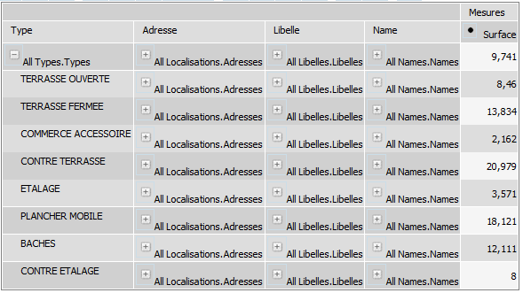

```python
from IPython.core.display import Image
Image(filename='Capture1.png')
```

### aperçu du cube OLAP sous workBench

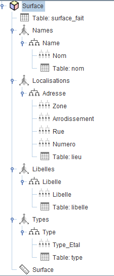

```python
Image(filename='Capture2.png')
```

# Aperçus des Datamarts: 2ème partie

## Schémas 2 et 3: Restaurants à Paris ou Avignon ayant subit un contrôle sanitaire en 2015

Nos deux prochains cubes ont pour base le fichier csv, accessible depuis le lien suivant: https://www.data.gouv.fr/fr/datasets/experimentation-de-la-mise-en-transparence-des-resultats-des-controles-officiels-en-restauration-commerciale-a-paris-et-avignon

Celui-ci recense toutes les contrôles sanitaires officiels réalisés durant l'année 2015. Les données rendues accessibles par la mise en transparence des résultats des contrôles officiels en hygiène alimentaire des restaurants.

Légende des Évaluations des restaurants:

- 30: Niveau d’hygiène « à améliorer ; mesures correctives requises » : il s’agit des établissements pour lesquels les déficiences constatées nécessitent la mise en place de mesures spécifiques (nettoyage, travaux, formation, …), mis en demeure de procéder à des mesures correctives, dont l’efficacité sera vérifiée lors d’un nouveau contrôle.
- 20: Niveau d’hygiène « acceptable » : établissements présentant des anomalies qui ne justifient pas l’application de mesures obligatoires par l’administration.
- 10: Niveau d’hygiène « bon » : établissements conformes à la réglementation ou présentant quelques anomalies mineures.

### Preprocessing:

Le fichier récupéré du site ci-dessus nous informe du nom, de la raison sociale et de son numéro de SIRET associé, du lieu (adresse et géoposition), de la date et de l'évaluation associée.

Nous avons choisit de combiner ces informations avec d'autres, dans l'optique de faire une analyse par rapport à l'évaluation et la côte vis-vis des consomateurs du restaurant ayant subi un contrôle. A l'aide de python et de BeautifulSoup, nous avons pu créer deux webscrappers:

- un qui, à partir de l'adresse et de l'enseigne du restaurant, se sert du moteur de recherche de yelp.fr afin de récupérer le restaurant, ainsi que les reviews et les ratings faits par les internautes. Des informations sur les reviewers sont également récupérés.
- et l'autre, qui, à partir du numéro de SIRET de l'entreprise possédant le restaurant, extrait les informations disponibles associées à l'entreprise: le capital, le type d'entreprise, etc...

### aperçu fichier.csv

```python
df2=pd.read_csv('Datamart Evaluations.csv',sep=';')
print(df2.shape)
df2.head()
```

```
(5118, 11)
```

|  | Evaluation | Nom | Annee | Mois | Jour | Ville | Arrondissement | capital | forme juridique | nombre etabl | rating |
| --- | --- | --- | --- | --- | --- | --- | --- | --- | --- | --- | --- |
| 0 | 20,00 | 2 BIS CAFE | 2 015,00 | 12,00 | 21,00 | PARIS | 5 | 7 622 | Soci�t� � responsabilit� limit�e (sans autre i... | 1,00 | 4,00 |
| 1 | 20,00 | 2 BIS CAFE | 2 015,00 | 12,00 | 21,00 | PARIS | 5 | 7 622 | Soci�t� � responsabilit� limit�e (sans autre i... | 1,00 | 3,00 |
| 2 | 20,00 | 2 BIS CAFE | 2 015,00 | 12,00 | 21,00 | PARIS | 5 | 7 622 | Soci�t� � responsabilit� limit�e (sans autre i... | 1,00 | 2,00 |
| 3 | 20,00 | 2 BIS CAFE | 2 015,00 | 12,00 | 21,00 | PARIS | 5 | 7 622 | Soci�t� � responsabilit� limit�e (sans autre i... | 1,00 | 1,00 |
| 4 | 20,00 | 2 BIS CAFE | 2 015,00 | 12,00 | 21,00 | PARIS | 5 | 7 622 | Soci�t� � responsabilit� limit�e (sans autre i... | 1,00 | 5,00 |

##### Ces données sont traitées et jointes à l'aide du logiciel Pentaho:

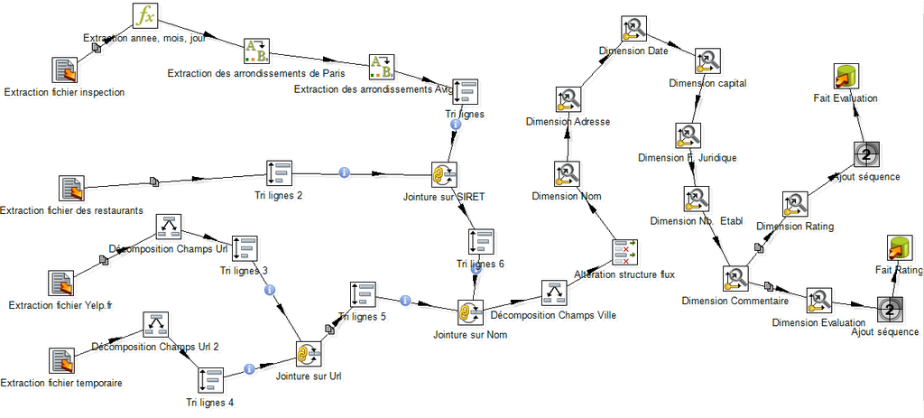

```python
Image(filename='Capture3.png')
```

## Datamart 2:

### Il en résulte les cubes suivants:

##### Cube du datamart 2 avec comme mesure l'evaluation sanitaire moyenne avec date d'inspection hiérarchisée

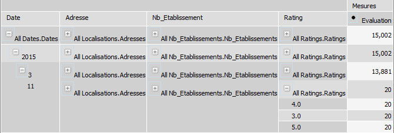

```python
Image(filename='Capture4.png')
```

## Datamart 3:

##### Cube du datamart 3 avec comme mesure les ratings moyens de Yelp.fr

Ce schéma utilise les mêmes données récoltés pour le deuxième datamart, mais la mesure n'est plus celle utilisée pour ce dernier: la mesure est maintenant les 'ratings' yelp attribués aux différents restaurants.

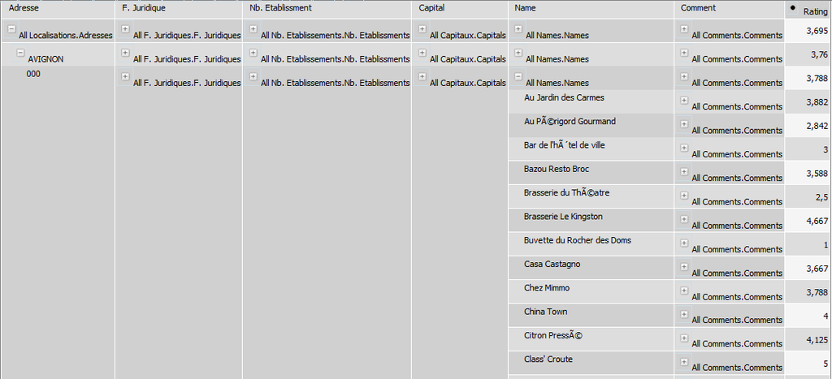

```python
Image(filename='Capture5.png')
```

# Quelques visualisations à la sortie des cubes

Une fois les cubes chargés sous Pentaho Server, nous avons pu faire des requête MDX pour extraire certaines informations que nous avons ensuite pu visualiser en utilisant Google Charts, accessible depuis le site suivant:

https://developers.google.com/chart/